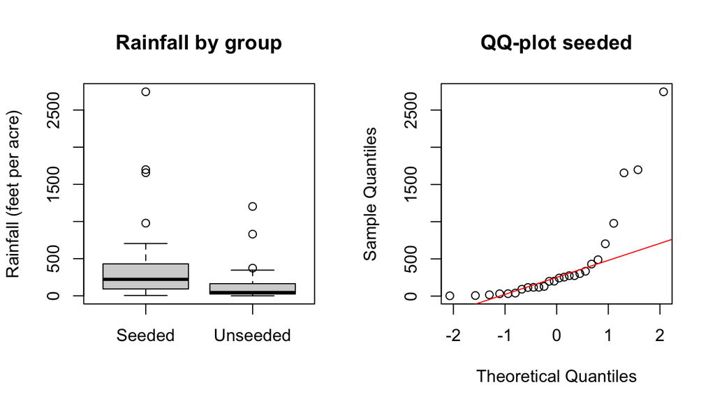

````yaml
---
output:
  pdf_document:
    latex_engine: xelatex
fontsize: 11pt
header-includes:
  - \usepackage{etoolbox}
  - \AtBeginEnvironment{verbatim}{\small}
---



Assignment 1 Experimental Design and Data Analysis
Group 57 - Layla Nolte, Jensen Valkenhoff, Richard Pereira e Silva

## Exercise 1a) Seeded clouds

We compare rainfall from **two independent samples** (26 seeded vs 26 unseeded clouds). The data are **not paired**, since different clouds were assigned to treatment and control groups.

The research question is whether **seeding increases rainfall**, so we mainly consider the one-sided alternative \(H_1:\mu_{\text{seeded}}>\mu_{\text{unseeded}}\), but we also report two-sided p-values.


``` r
options(digits = 3)

# Load data
clouds <- read.table("clouds.txt", header = TRUE)
seeded <- clouds$seeded
unseeded <- clouds$unseeded

# Visual check: skewness/outliers
par(mfrow=c(1,2))
boxplot(seeded, unseeded, names=c("Seeded","Unseeded"),
        main="Rainfall by group", ylab="Rainfall (feet per acre)")
qqnorm(seeded, main="QQ-plot seeded"); qqline(seeded, col="red")
````

```r
par(mfrow=c(1,1))

# Tests
tt_two <- t.test(seeded, unseeded, alternative="two.sided")   # Welch
tt_gre <- t.test(seeded, unseeded, alternative="greater")

mw_two <- wilcox.test(seeded, unseeded, alternative="two.sided", exact=FALSE)
mw_gre <- wilcox.test(seeded, unseeded, alternative="greater", exact=FALSE)

ks_two <- ks.test(seeded, unseeded, alternative="two.sided")

# Short p-value table (only relevant lines)
pvals <- data.frame(
  Test = c("Welch t-test", "Mann–Whitney", "KS test"),
  `p (two-sided)` = c(tt_two$p.value, mw_two$p.value, ks_two$p.value),
  `p (seeded > unseeded)` = c(tt_gre$p.value, mw_gre$p.value, NA)
)
pvals
```

```
##           Test p..two.sided. p..seeded...unseeded.
## 1 Welch t-test        0.0538               0.02688
## 2 Mann–Whitney        0.0138               0.00692
## 3      KS test        0.0177                    NA
```

```r
# Short conclusion text (auto-generated so it matches the numbers)
cat("\nConclusion (alpha = 0.05):\n")
```

```
##
## Conclusion (alpha = 0.05):
```

```r
cat(sprintf("- Welch t-test: two-sided p = %.4f; one-sided (seeded > unseeded) p = %.4f.\n",
            tt_two$p.value, tt_gre$p.value))
```

```
## - Welch t-test: two-sided p = 0.0538; one-sided (seeded > unseeded) p = 0.0269.
```

```r
cat(sprintf("- Mann–Whitney: two-sided p = %.4f; one-sided p = %.4f.\n",
            mw_two$p.value, mw_gre$p.value))
```

```
## - Mann–Whitney: two-sided p = 0.0138; one-sided p = 0.0069.
```

```r
cat(sprintf("- KS test (two-sided): p = %.4f.\n", ks_two$p.value))
```

```
## - KS test (two-sided): p = 0.0177.
```

```r
cat("\nInterpretation:\n")
```

```
##
## Interpretation:
```

```r
cat("Rainfall is highly skewed with extreme values, so the t-test assumptions are questionable.\n")
```

```
## Rainfall is highly skewed with extreme values, so the t-test assumptions are questionable.
```

```r
cat("Nonparametric tests (Mann–Whitney and KS) indicate a significant difference between groups.\n")
```

```
## Nonparametric tests (Mann–Whitney and KS) indicate a significant difference between groups.
```

```r
cat("Because assignment to seeded/unseeded clouds was randomized, a permutation test is applicable and valid.\n")
```

```
## Because assignment to seeded/unseeded clouds was randomized, a permutation test is applicable and valid.
```

Applicability.

Welch t-test targets means and is sensitive to skewness/outliers.

Mann–Whitney compares location (often interpreted as median shift under assumptions).

KS compares entire distributions. A permutation test is applicable because treatment assignment was randomized.

## Exercise 1b) Transformations of rainfall

To reduce skewness and stabilize variance, we repeat the analysis using the square root and the fourth root (sqrt of sqrt) transformations of rainfall.

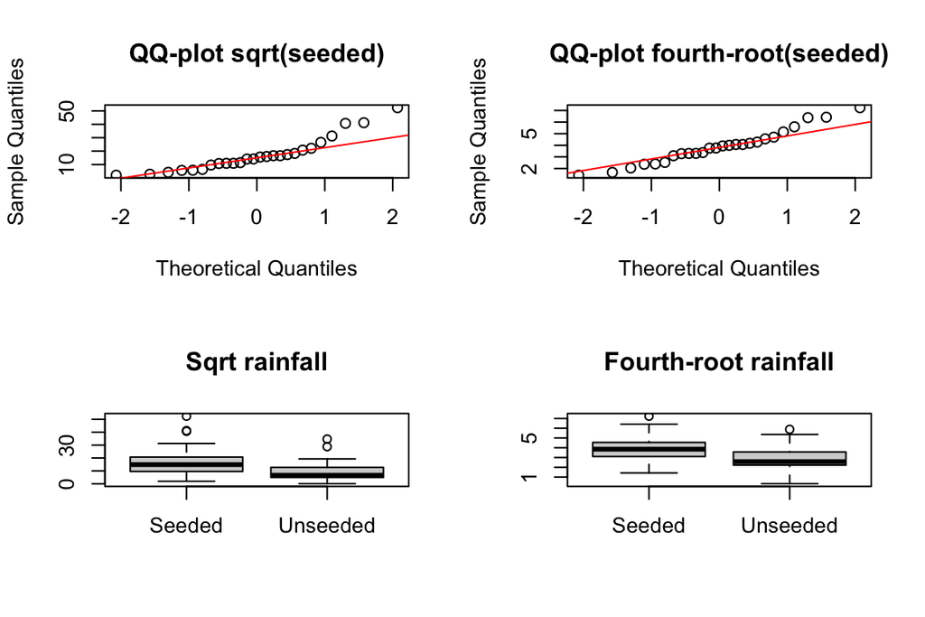

```r
options(digits = 3)

clouds <- read.table("clouds.txt", header = TRUE)
seeded <- clouds$seeded
unseeded <- clouds$unseeded

seeded_sqrt  <- sqrt(seeded)
unseeded_sqrt <- sqrt(unseeded)

seeded_4rt  <- sqrt(seeded_sqrt)
unseeded_4rt <- sqrt(unseeded_sqrt)

par(mfrow=c(2,2))

qqnorm(seeded_sqrt, main="QQ-plot sqrt(seeded)")
qqline(seeded_sqrt, col="red")

qqnorm(seeded_4rt, main="QQ-plot fourth-root(seeded)")
qqline(seeded_4rt, col="red")

boxplot(seeded_sqrt, unseeded_sqrt,
        names=c("Seeded","Unseeded"),
        main="Sqrt rainfall")

boxplot(seeded_4rt, unseeded_4rt,
        names=c("Seeded","Unseeded"),
        main="Fourth-root rainfall")
```

```r
par(mfrow=c(1,1))

tt_sqrt  <- t.test(seeded_sqrt, unseeded_sqrt, alternative="greater")
mw_sqrt  <- wilcox.test(seeded_sqrt, unseeded_sqrt, alternative="greater", exact=FALSE)
ks_sqrt  <- ks.test(seeded_sqrt, unseeded_sqrt)

tt_4rt  <- t.test(seeded_4rt, unseeded_4rt, alternative="greater")
mw_4rt  <- wilcox.test(seeded_4rt, unseeded_4rt, alternative="greater", exact=FALSE)
ks_4rt  <- ks.test(seeded_4rt, unseeded_4rt)

results_1b <- data.frame(
  Transformation = c("Sqrt", "Fourth-root"),
  `Welch p` = c(tt_sqrt$p.value, tt_4rt$p.value),
  `Mann-Whitney p` = c(mw_sqrt$p.value, mw_4rt$p.value),
  `KS (two-sided) p` = c(ks_sqrt$p.value, ks_4rt$p.value)
)

results_1b
```

```
##   Transformation Welch.p Mann.Whitney.p KS..two.sided..p
## 1           Sqrt 0.00978        0.00692           0.0177
## 2    Fourth-root 0.00620        0.00692           0.0177
```

The square-root transformation reduces skewness compared to the original data, and the fourth-root transformation improves symmetry even further, as seen in the QQ-plots.

After transformation, the Welch t-test becomes more reliable because the normality assumption is better satisfied. The significance levels remain similar, and the evidence that seeded clouds produce more rainfall persists.

The nonparametric tests (Mann–Whitney and KS) are largely unaffected by transformation, since they do not rely on normality assumptions.

Overall, the conclusion from Exercise 1a remains unchanged: there is evidence that seeding increases rainfall.

## Exercise 1c) Testing Population Mean

```r
options(digits=3)

# Exercise 1
clouds = read.table("clouds.txt", header=TRUE)

t1=sqrt(sqrt(clouds$seeded))
mean(t1)
```

```
## [1] 3.88
```

```r
mu3 <- t.test(t1, alternative = "greater", mu=3)
mu4 <- t.test(t1, alternative = "greater", mu=4)
mu3_5 <- t.test(t1, alternative = "greater", mu=3.5)

# Sign test
sum(t1>3)
```

```
## [1] 20
```

```r
binom.test(20,26,alt="g",p=0.5)
```

```
##
##  Exact binomial test
##
## data:  20 and 26
## number of successes = 20, number of trials = 26, p-value = 0.005
## alternative hypothesis: true probability of success is greater than 0.5
## 95 percent confidence interval:
##  0.595 1.000
## sample estimates:
## probability of success
##                  0.769
```

```r
wilcox.test(t1,mu=3,alt="g", exact = FALSE)
```

```
##
##  Wilcoxon signed rank test with continuity correction
##
## data:  t1
## V = 280, p-value = 0.004
## alternative hypothesis: true location is greater than 3
```

```r
results_1c <- data.frame(
  Transformation = c("P-Value"),
  `Mu = 3` = c(mu3$p.value),
  `Mu = 4` = c(mu4$p.value),
  `M = 3.5` = c(mu3_5$p.value)
)

results_1c
```

```
##   Transformation  Mu...3 Mu...4 M...3.5
## 1        P-Value 0.00242  0.663  0.0973
```